# INFSCI 2595 Final Project

Part 2D2 Regression Resampling ENET

Radhika Purohit

```r
knitr::opts_chunk$set(echo = TRUE)
```

```r
library(tidyverse)
```

```r
theme_set(theme_linedraw())
library(tidymodels)
tidymodels_prefer()
```

```r
df <- readr::read_csv("paint_project_train_data.csv", col_names = TRUE)
dfii <- df %>%
  mutate(y = boot::logit( (response - 0) / (100 - 0) ) ) %>%
  select(R, G, B,
         Lightness, Saturation, Hue,
         y)

dfii %>% glimpse()
```

```
## Rows: 835
## Columns: 7
## $ R          <dbl> 172, 26, 172, 28, 170, 175, 90, 194, 171, 122, 0, 88, 144, …
## $ G          <dbl> 58, 88, 94, 87, 66, 89, 78, 106, 68, 151, 121, 140, 82, 163…
## $ B          <dbl> 62, 151, 58, 152, 58, 65, 136, 53, 107, 59, 88, 58, 132, 50…
## $ Lightness  <chr> "dark", "dark", "dark", "dark", "dark", "dark", "dark", "da…
## $ Saturation <chr> "bright", "bright", "bright", "bright", "bright", "bright",…
## $ Hue        <dbl> 4, 31, 8, 32, 5, 6, 34, 10, 1, 21, 24, 22, 36, 16, 26, 12, …
## $ y          <dbl> -1.9924302, -2.1972246, -1.6582281, -2.1972246, -2.0907411,…
```

## Elastic Net

Use Elastic Net to provide regularization to the two complex models that resulted extreme poor performances during the resampling.

### Models

**Define the linear models to tune with Elastic Net.**

**The preprocessing steps**

```r
bp_prep <- recipe(y ~ ., data=dfii) %>%
  step_normalize(all_numeric_predictors())
  # prep(training=df_regr, retain=T) %>% bake(new_data=NULL)
```

**`D2_model1`: All pairwise interactions of continuous inputs, include additive categorical features.**

```r
D2_model1 <- bp_prep %>%
  step_interact(~ all_numeric_predictors():all_numeric_predictors(), sep = ":") %>%
  step_dummy(all_nominal_predictors())
```

**`D2_model2`: Interaction of the categorical inputs with all continuous inputs main effects**  
(The more complex of the two models selected previously)

```r
D2_model2 <- bp_prep %>%
  step_interact(~ all_nominal_predictors():all_numeric_predictors(), sep = ":") %>%
  step_dummy(all_nominal_predictors())
```

## Tuning

### Explore

**First use Lasso to explore the range for parameter tuning.**

**Define the Lasso only model specification.**

```r
lasso_explore_spec <-
  linear_reg(penalty = 0.1, mixture = 1) %>%
  set_engine("glmnet", intercept = TRUE)
```

**Fit both models with Lasso.**

```r
lasso_fit_2D2 <- workflow() %>%
  add_model(lasso_explore_spec) %>%
  add_recipe(D2_model1) %>%
  fit(dfii)

lasso_fit_2D5 <- workflow() %>%
  add_model(lasso_explore_spec) %>%
  add_recipe(D2_model2) %>%
  fit(dfii)
```

**Generate the coefficient paths.**

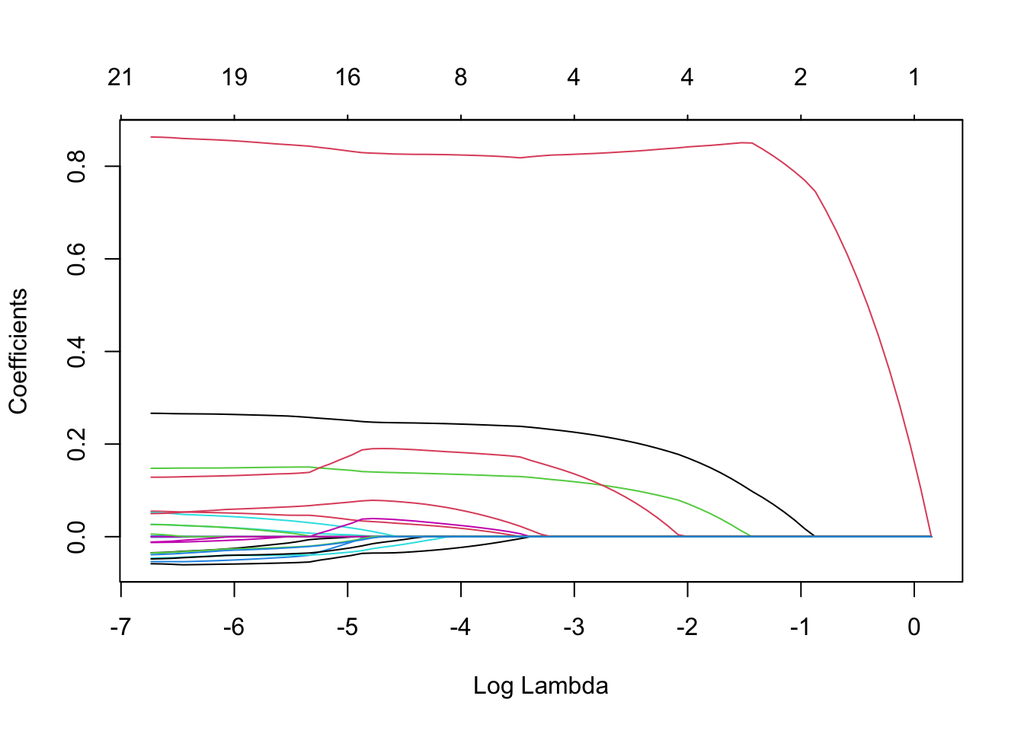

```r
lasso_fit_2D2 %>% extract_fit_parsnip() %>%
  pluck('fit') %>%
  plot(xvar = 'lambda')
```

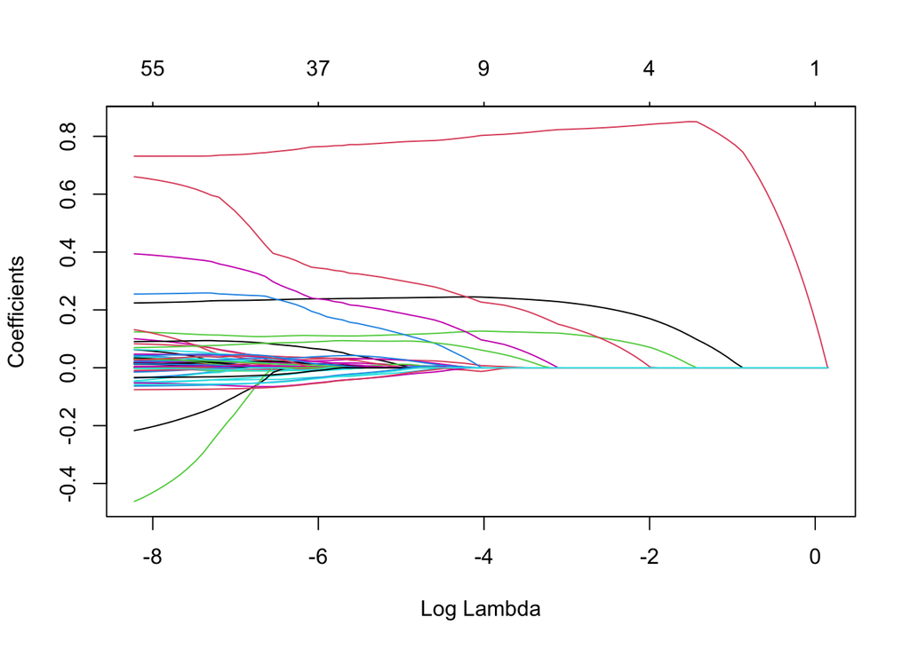

```r
lasso_fit_2D5 %>% extract_fit_parsnip() %>%
  pluck('fit') %>%
  plot(xvar = 'lambda')
```

### Setup

**Create the custom search grid for the penalty strength and mixing fraction parameters.**

- Use the bound of penalty strength for the range of parameters I am interested to tune.
- Use 0.1 as lower bound for mixing fraction to avoid fully Ridge.

```r
# set tuning parameter ranges
my_lambda <- penalty(range = c(-6,-1), trans = log_trans())
my_alpha <- dials::mixture(range = c(0.1, 1.0))
# construct the tuning grid
enet_grid <- grid_regular(
  my_lambda, my_alpha,
  levels = c(penalty = 80, mixture = 5))
```

**Define the resampling scheme**

- Use the 5-fold cross-validation with 5 repeats.
- Model specification: use `glmnet` engine.

```r
set.seed(1324)
cv_folds <- vfold_cv(dfii, v = 5, repeats = 5)
my_metrics <- metric_set(rmse, mae, rsq)
```

**Create workflow set.**

```r
enet_spec <-
  linear_reg(penalty = tune(), mixture = tune()) %>%
  set_engine("glmnet", intercept = TRUE, standardize = TRUE)

enet_wset <-
  workflow_set(
    preproc = list(
      all_cont_pairwise = D2_model1,
      all_cont_categorical = D2_model2
      ),
    models = list(enet = enet_spec)
  )
```

### Execute

```r
# create cluster to allow parallel computing
if (parallel::detectCores(logical=FALSE) > 3) {
  library(doParallel)
  num_cores <- parallel::detectCores(logical=FALSE)
  cl <- makePSOCKcluster(num_cores - 2)
  registerDoParallel(cl)
}
# start tuning
tune_2D_enet <- enet_wset %>%
  workflow_map(
    fn = "tune_grid",
    grid = enet_grid,
    resamples = cv_folds,
    metrics = my_metrics,
    control = control_grid(
      # save_pred = TRUE,
      parallel_over = "everything",
      save_workflow = TRUE
    ),
    verbose = T
  )
```

```
## i 1 of 2 tuning:     all_cont_pairwise_enet
```

```
## ✔ 1 of 2 tuning:     all_cont_pairwise_enet (15.2s)
```

```
## i 2 of 2 tuning:     all_cont_categorical_enet
```

```
## ✔ 2 of 2 tuning:     all_cont_categorical_enet (5.8s)
```

```r
# close the cluster
stopCluster(cl)
registerDoSEQ()
```

```r
tune_2D_enet %>% readr::write_rds("tune_2D_enet.rds")
```

## Conclusions

```r
names(tune_2D_enet$result) <- tune_2D_enet$wflow_id
```

### Performance

**Visualize the model performance metrics across the two models tuned.**

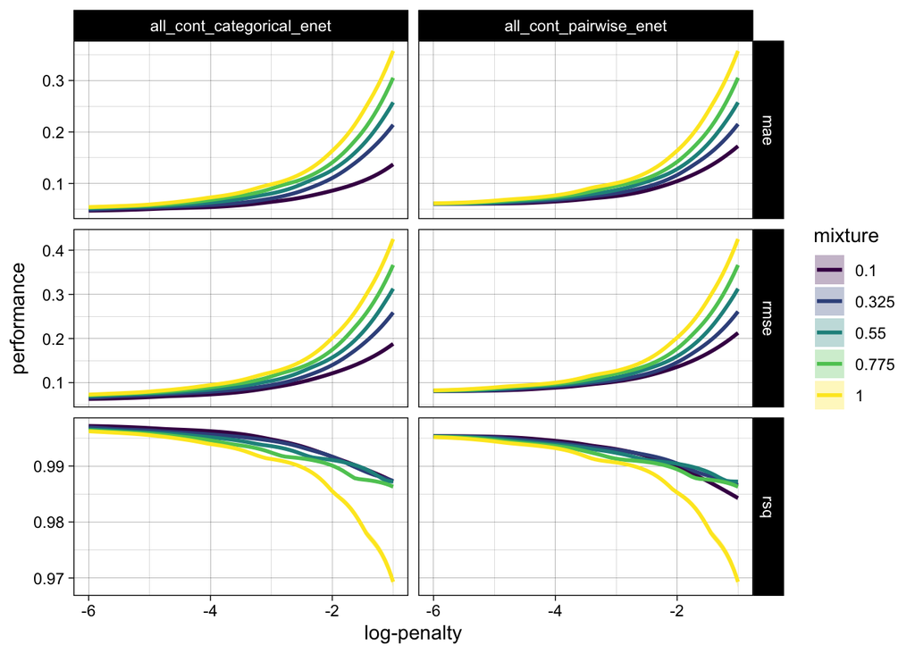

```r
tune_2D_enet$result %>%
  map_dfr(collect_metrics, .id="wflow_id") %>%
  ggplot(aes(x = log(penalty))) +
  geom_ribbon(
    aes(ymin = mean - std_err, ymax = mean + std_err,
        group = interaction(mixture, .metric),
        fill = as.factor(mixture)),
    alpha = 0.3) +
  geom_line(
    aes(y = mean,
        group = interaction(mixture, .metric),
        color = as.factor(mixture)),
    size = 1) +
  facet_grid(.metric ~ wflow_id, scales = "free_y") +
  xlab("log-penalty") + ylab("performance") + labs(color="mixture", fill="mixture") +
  scale_color_viridis_d() + scale_fill_viridis_d()
```

- Elastic Net prefers Ridge over Lasso (small mixture fraction). This is as expected because some inputs are correlated, which can make Lasso struggle.

### Best Model

**Select the best tuning parameters for each model based on RMSE.**

```r
enet_best_rmse_params <-
  tune_2D_enet$result %>%
  map_dfr(select_by_pct_loss, desc(mixture), metric = 'rmse', .id = "wflow_id")
enet_best_rmse_params %>% select(-starts_with("."))
```

```
## # A tibble: 2 × 6
##   wflow_id                  penalty mixture   mean     n  std_err
##   <chr>                       <dbl>   <dbl>  <dbl> <int>    <dbl>
## 1 all_cont_pairwise_enet    0.00248     1   0.0825    25 0.00122
## 2 all_cont_categorical_enet 0.00248     0.1 0.0630    25 0.000918
```

**Visualize all three performance metrics for the best models.**

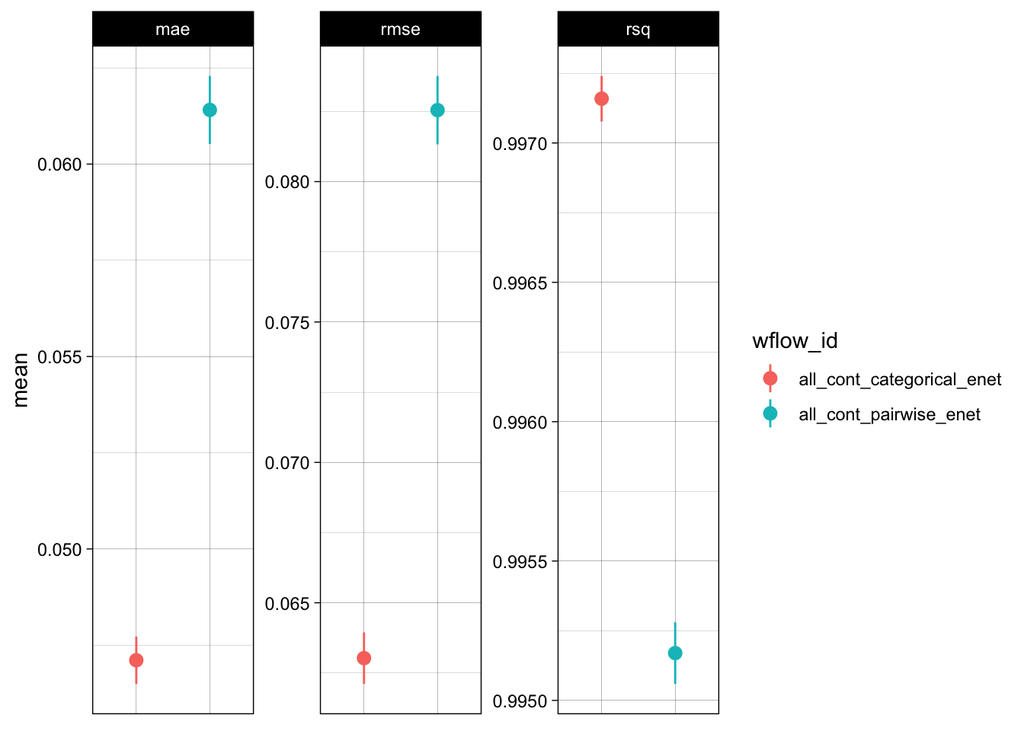

```r
tune_2D_enet %>% collect_metrics() %>%
  inner_join(enet_best_rmse_params %>% select(wflow_id, .config), by = c("wflow_id", ".config")) %>%
  ggplot(aes(color = wflow_id, x = wflow_id)) +
  geom_pointrange(aes(y=mean, ymax=mean+std_err, ymin=mean-std_err)) +
  facet_wrap(~ .metric, scales = "free_y") +
  theme(axis.text.x = element_blank(), axis.ticks.x = element_blank()) +
  xlab(label = NULL)
```

- The “all_cont_categorical_enet” one is the clear winner as it has lower RMSE/MAE and higher R-Squared than the other model.

**Fit both best models and examine the number of non-zero coefficients.**

```r
enet_wset %>%
  extract_workflow("all_cont_categorical_enet") %>%
  finalize_workflow(parameters = enet_best_rmse_params %>% slice(1)) %>%
  fit(dfii) %>%
  tidy() %>% filter(estimate != 0) %>% nrow()
```

```
## [1] 38
```

```r
enet_wset %>%
    extract_workflow("all_cont_pairwise_enet") %>%
    finalize_workflow(parameters = enet_best_rmse_params %>% slice(2)) %>%
  fit(dfii) %>%
  tidy() %>% filter(estimate != 0) %>% nrow()
```

```
## [1] 21
```

**Finalize the workflow for the best model and retrain with resampling to save predictions.**

```r
enet_best_wflow_mae <- "all_cont_categorical_enet"
enet_best_param <- enet_best_rmse_params %>%
      filter(wflow_id==enet_best_wflow_mae) %>%
      select(all_of(names(enet_grid)))

mod_2D_enet_best_wflow <-
  enet_wset %>%
  extract_workflow(enet_best_wflow_mae) %>%
  finalize_workflow(parameters = enet_best_param)
mod_2D_enet_best_wflow$param <- enet_best_param

mod_2D_enet_best_resample <-
  mod_2D_enet_best_wflow %>%
  fit_resamples(
    resamples = cv_folds,
    metrics = my_metrics,
    control = control_resamples(save_pred = T)
  )

mod_2D_enet_best_resample %>% collect_metrics() %>% select(-.config, -.estimator)
```

```
## # A tibble: 3 × 4
##   .metric   mean     n   std_err
##   <chr>    <dbl> <int>     <dbl>
## 1 mae     0.0471    25 0.000616
## 2 rmse    0.0630    25 0.000918
## 3 rsq     0.997     25 0.0000818
```

```r
mod_2D_enet_best_wflow %>% readr::write_rds("mod_2D_enet_best_wflow.rds")
mod_2D_enet_best_resample %>% readr::write_rds("mod_2D_enet_best_resample.rds")
```